# AS2-1: 數位偵探

Group-00

2022-03-02 13:21:15

犯罪是一個國際關注的問題，但它在不同的國家以不同的方式記錄和處理。 在美國，聯邦調查局（FBI）記錄了暴力犯罪和財產犯罪。 此外，每個城市都記錄了犯罪行為，一些城市發布了有關犯罪率的數據。 伊利諾伊州芝加哥市從2001年開始在線發布犯罪數據。 芝加哥是美國人口第三多的城市，人口超過270萬。 在這個作業裡面，我們將關注一種特定類型的財產犯罪，稱為「汽車盜竊」， 我們將使用R中的一些基本數據分析來了解芝加哥的汽車盜竊紀錄。 請載入文件“data/mvtWeek1.csv”。

🌻 以下是各欄位的定義：

- `ID`: 事件ID
- `Date`: 日期與時間
- `LocationDescription`: 失竊地點
- `Arrest`: 是否破案
- `Domestic`: 是否為家庭犯罪
- `Beat`: 小區代碼
- `District`: 區碼
- `CommunityArea`: 社區代碼
- `Year`: 年分
- `Latitude`: 緯度
- `Longitude`: 經度

🌻 藉由分析這些紀錄，我們可以：

- 了解「汽車盜竊」事件的整體狀況和趨勢
- 描述「汽車盜竊」事件在時、空間之中的分佈狀況
- 做為警力配置的參考

🌻 這個練習的學習重點是：

- 字串和日期(時間)資料的轉換
- 練習使用分類計數和分類統計功能 `table` and `tapply`

### Section-1 Loading the Data

Read the data into a data frame `D`.

```r
D = read.csv("data/mvtWeek1.csv")
```

As I said, the names of your major data frame is the shorter the better.

【1.1】How many rows of data (observations) are in this dataset?

```r
nrow(D)
```

```
[1] 191641
```

```r
#191641
```

【1.2】How many variables are in this dataset?

```r
ncol(D)
```

```
[1] 11
```

```r
#11
```

Let’s also check the data types of these variables

```r
str(D)
```

```
'data.frame':   191641 obs. of  11 variables:
 $ ID                 : int  8951354 8951141 8952745 8952223 8951608 8950793 8950760 8951611 8951802 8950706 ...
 $ Date               : chr  "12/31/12 23:15" "12/31/12 22:00" "12/31/12 22:00" "12/31/12 22:00" ...
 $ LocationDescription: chr  "STREET" "STREET" "RESIDENTIAL YARD (FRONT/BACK)" "STREET" ...
 $ Arrest             : logi  FALSE FALSE FALSE FALSE FALSE TRUE ...
 $ Domestic           : logi  FALSE FALSE FALSE FALSE FALSE FALSE ...
 $ Beat               : int  623 1213 1622 724 211 2521 423 231 1021 1215 ...
 $ District           : int  6 12 16 7 2 25 4 2 10 12 ...
 $ CommunityArea      : int  69 24 11 67 35 19 48 40 29 24 ...
 $ Year               : int  2012 2012 2012 2012 2012 2012 2012 2012 2012 2012 ...
 $ Latitude           : num  41.8 41.9 42 41.8 41.8 ...
 $ Longitude          : num  -87.6 -87.7 -87.8 -87.7 -87.6 ...
```

```r
#$ ID                 : int
#$ Date               : chr
#$ LocationDescription: chr
#$ Arrest             : logi
#$ Domestic           : logi
#$ Beat               : int
#$ District           : int
#$ CommunityArea      : int
#$ Year               : int
#$ Latitude           : num
#$ Longitude          : num
```

and do a quick summary on them.

```r
summary(D)
```

```
       ID              Date           LocationDescription   Arrest         Domestic
 Min.   :1310022   Length:191641      Length:191641       Mode :logical   Mode :logical
 1st Qu.:2832144   Class :character   Class :character    FALSE:176105    FALSE:191226
 Median :4762956   Mode  :character   Mode  :character    TRUE :15536     TRUE :415
 Mean   :4968629
 3rd Qu.:7201878
 Max.   :9181151

      Beat         District     CommunityArea        Year         Latitude
 Min.   : 111   Min.   : 1      Min.   : 0      Min.   :2001   Min.   :41.6
 1st Qu.: 722   1st Qu.: 6      1st Qu.:22      1st Qu.:2003   1st Qu.:41.8
 Median :1121   Median :10      Median :32      Median :2006   Median :41.9
 Mean   :1259   Mean   :12      Mean   :38      Mean   :2006   Mean   :41.8
 3rd Qu.:1733   3rd Qu.:17      3rd Qu.:60      3rd Qu.:2009   3rd Qu.:41.9
 Max.   :2535   Max.   :31      Max.   :77      Max.   :2012   Max.   :42.0
                NA's   :43056   NA's   :24616                  NA's   :2276
   Longitude
 Min.   :-87.9
 1st Qu.:-87.7
 Median :-87.7
 Mean   :-87.7
 3rd Qu.:-87.6
 Max.   :-87.5
 NA's   :2276
```

【1.3】Using the “max” function, what is the maximum value of the variable `ID`?

```r
max(D$ID)
```

```
[1] 9181151
```

【1.4】 What is the minimum value of the variable `Beat`?

```r
min(D$Beat)
```

```
[1] 111
```

【1.5】 How many observations have value TRUE in the `Arrest` variable (this is the number of crimes for which an arrest was made)?

```r
sum(D$Arrest)
```

```
[1] 15536
```

What is the average arrest rate of car thief events?

```r
mean(D$Arrest)
```

```
[1] 0.08107
```

【1.6】 How many observations have a `LocationDescription` value of `ALLEY`?

```r
sum(D['LocationDescription']=='ALLEY')
```

```
[1] 2308
```

### Section-2 Processing Date and Time in R

【2.1】 In what format are the entries in the variable Date?

- Month/Day/Year Hour:Minute
- Day/Month/Year Hour:Minute
- Hour:Minute Month/Day/Year
- Hour:Minute Day/Month/Year

```r
head(D$Date)  # Month/Day/Year Hour:Minute
```

```
[1] "12/31/12 23:15" "12/31/12 22:00" "12/31/12 22:00" "12/31/12 22:00" "12/31/12 21:30"
[6] "12/31/12 20:30"
```

🌞 Date and Time are quite troublesome. Naturally the time line is a rational linear dimension. However, these nice real-number properties are all messed up in human society. Months have different days. Week may span over two months. The worst is, people record date and time in so many different formats that computers cannot read them automatically. Therefore, dates and time are usually read in as character strings. We have to manually look into the strings, recognize the format and then convert them into `Date` or `POSIXct` (name of a standard timing system) data types before we can properly using them in our programs. For an example, we need to observe the format in `D$date` and convert this `chr` column into a `POSIXct` vector (`ts`).

```r
ts = as.POSIXct(D$Date, format="%m/%d/%y %H:%M")
```

🌻 `as.POSIXct(x, format)` converts a string vector `x` into a `POSIXct` vector.

🌷 Watch how format of the time string is specified in Date and Time Codes (see Table-1 below)

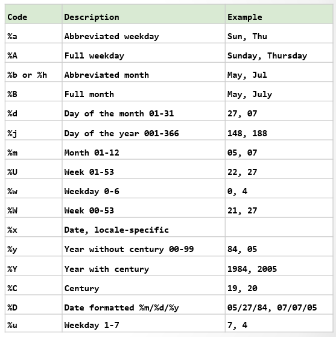

Table-1 Date and Time Formatting Codes

Now we can make histograms of this time variable (`ts`) in the same way as we do for numerics …

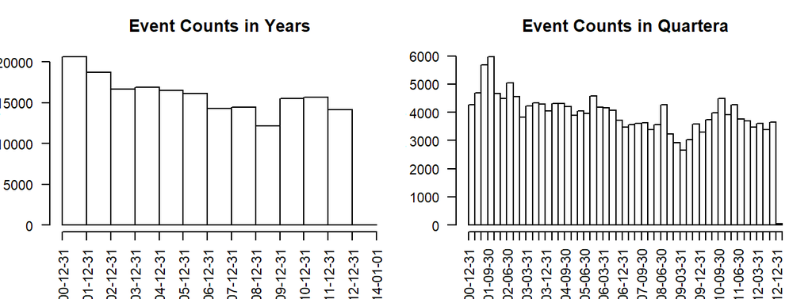

```r
par(mfrow=c(1,2), mar=c(4,3,3,1), cex=0.7)
hist(ts,"year",las=2,freq=T,xlab="",main="Event Counts in Years")
hist(ts,"quarter",las=2,freq=T,xlab="",main="Event Counts in Quartera")
```

🌻 `format()` can convert date/times back to strings in the desirable format

For examples, if we want to count the car thief events by weekdays …

```r
table( format(ts,'%w') )
```

```
    0     1     2     3     4     5     6
26316 27397 26791 27416 27319 29284 27118
```

by hours …

```r
table( format(ts,'%H') )
```

```
   00    01    02    03    04    05    06    07    08    09    10    11    12    13    14
13212  6643  5377  4202  3357  3728  5136  6852  7866  8136  6566  5415  8158  5555  6419
   15    16    17    18    19    20    21    22    23
 7512  7736  8635 10521 10427 11716 12434 14745 11293
```

by 7 days and 24 hours …

```r
table(weekday=format(ts,'%u'), month=format(ts,'%H'))
```

```
       month
weekday   00   01   02   03   04   05   06   07   08   09   10   11   12   13   14   15
      1 1900  825  712  527  415  542  772 1123 1323 1235  971  737 1129  824  958 1059
      2 1691  777  603  464  414  520  845 1118 1175 1174  948  786 1108  762  908 1071
      3 1814  790  619  469  396  561  862 1140 1329 1237  947  763 1225  804  863 1075
      4 1856  816  696  508  400  534  799 1135 1298 1301  932  731 1093  752  831 1044
      5 1873  932  743  560  473  602  839 1203 1268 1286  938  822 1207  857  937 1140
      6 2050 1267  985  836  652  508  541  650  858 1039  946  789 1204  767  963 1086
      7 2028 1236 1019  838  607  461  478  483  615  864  884  787 1192  789  959 1037
       month
weekday   16   17   18   19   20   21   22   23
      1 1136 1252 1518 1503 1622 1815 2009 1490
      2 1090 1274 1553 1496 1696 1816 2044 1458
      3 1076 1289 1580 1507 1718 1748 2093 1511
      4 1131 1258 1510 1537 1668 1776 2134 1579
      5 1165 1318 1623 1652 1736 1881 2308 1921
      6 1055 1084 1348 1390 1570 1702 2078 1750
      7 1083 1160 1389 1342 1706 1696 2079 1584
```

With a few more line of codes we can transform the table into a heatmap that illustrates the time distribution of car thief events nicely. The plotting function will be elaborated latter in this course

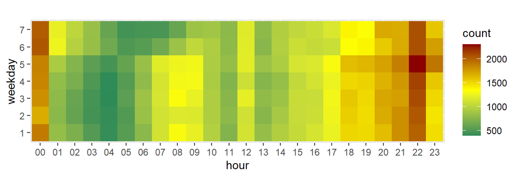

```r
table(format(ts,"%u"), format(ts,"%H")) %>%
  as.data.frame() %>% setNames(c("weekday","hour","count")) %>%
  ggplot(aes(hour,weekday,fill=count)) +   #fill:上色
  geom_tile() + coord_fixed(ratio=1) +     #tile:熱圖、coord:小方框
  scale_fill_gradientn(colors=c("seagreen","yellow","darkred"))
```

```r
  #可帶n種顏色
```

💡 Hints: The most useful functions in R are …  
■ `table()`  
■ `tapply()`  
incorporating with …  
■ `sort()`, `head()`, `tail()`  
■ `sum()`, `mean`, `max()`, `min`  
You should be able to solve all fo the questions below

【2.2】 What is the month and year of the **median** date in our dataset?

```r
format(median((ts)),'%m')
```

```
[1] "05"
```

```r
format(median((ts)),'%Y')
```

```
[1] "2006"
```

【2.3】 In which month did the fewest motor vehicle thefts occur?

```r
min(table(format(ts,'%m')))
```

```
[1] 13511
```

```r
x=(table(format(ts,'%m')))
x
```

```
   01    02    03    04    05    06    07    08    09    10    11    12
16047 13511 15758 15280 16035 16002 16801 16572 16060 17086 16063 16426
```

```r
names(x)[x==min(x)]
```

```
[1] "02"
```

【2.4】 On which weekday did the most motor vehicle thefts occur?

```r
table(format(ts,'%u'))
```

```
    1     2     3     4     5     6     7
27397 26791 27416 27319 29284 27118 26316
```

```r
y = table(format(ts,'%u'))
names(y)[y==max(y)]
```

```
[1] "5"
```

【2.5】 Which month has the largest number of motor vehicle thefts for which an arrest was made?

```r
max(table(format(ts,'%m'),D$Arrest)[,2])
```

```
[1] 1435
```

```r
z = table(format(ts,'%m'),D$Arrest)[,2]
names(z)[z==max(z)]
```

```
[1] "01"
```

```r
table( format(ts[D$Arrest %in% TRUE],'%m'))
```

```
  01   02   03   04   05   06   07   08   09   10   11   12
1435 1238 1298 1252 1187 1230 1324 1329 1248 1342 1256 1397
```

### Section-3 Visualizing Crime Trends

【3.1】 In general …

- does it look like crime increases or decreases from 2002 - 2012?
- does it look like crime increases or decreases from 2005 - 2008?
- does it look like crime increases or decreases from 2009 - 2011?

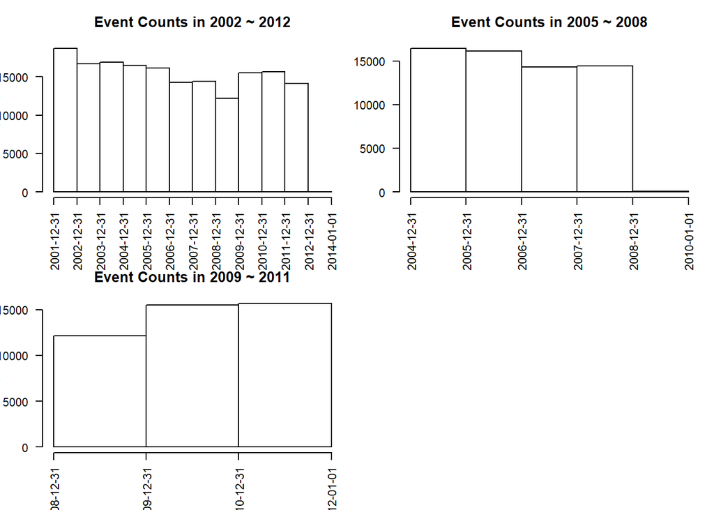

```r
par(mfrow=c(2,2), mar=c(4,3,3,1), cex=0.7)

# 2002年到2012年逐年的犯罪數
subset(ts, format(ts, '%Y') >= 2002 & format(ts, '%Y') <= 2012) %>%
  hist("year",las=2,freq=T,xlab="",main="Event Counts in 2002 ~ 2012")
# 逐年減少，但在2010年和2011年有回升的趨勢

# 2005年到2008年逐年的犯罪數
subset(ts, format(ts, '%Y') >= 2005 & format(ts, '%Y') <= 2008) %>%
  hist("year",las=2,freq=T,xlab="",main="Event Counts in 2005 ~ 2008")
# 逐年下降的趨勢

# 2009年到2011年逐年的犯罪數
subset(ts, format(ts, '%Y') >= 2009 & format(ts, '%Y') <= 2011) %>%
  hist("year",las=2,freq=T,xlab="",main="Event Counts in 2009 ~ 2011")
# 逐年提升的趨勢，可能跟金融風暴有關
```

【3.2】 Does it look like there were more crimes for which arrests were made in the first half of the time period or the second half of the time period?

```r
# 在前半時段還是後半時段破案數較多
table(format(subset(ts, D$Arrest == T), '%Y') >= 2007)
```

```
FALSE  TRUE
10588  4948
```

```r
table(format(subset(ts, D$Arrest == T), '%Y') >= 2006)
```

```
FALSE  TRUE
 9286  6250
```

```r
table(format(subset(ts, D$Arrest == T), '%Y'))
```

```
2001 2002 2003 2004 2005 2006 2007 2008 2009 2010 2011 2012
2152 2115 1798 1693 1528 1302 1212 1020  840  701  625  550
```

```r
# 前半時段破案數較多
```

【3.3】 For what proportion of motor vehicle thefts in 2001 was an arrest made?

```r
prop.table(table(D$Arrest,format(ts,'%Y')),2)
```

```
           2001    2002    2003    2004    2005    2006    2007    2008    2009    2010
  FALSE 0.89588 0.88722 0.89206 0.89960 0.90730 0.91912 0.91513 0.92939 0.93096 0.95477
  TRUE  0.10412 0.11278 0.10794 0.10040 0.09270 0.08088 0.08487 0.07061 0.06904 0.04523

           2011    2012
  FALSE 0.96003 0.96097
  TRUE  0.03997 0.03903
```

```r
v = table(D$Arrest,format(ts,'%Y')) %>% prop.table(2)
v
```

```
           2001    2002    2003    2004    2005    2006    2007    2008    2009    2010
  FALSE 0.89588 0.88722 0.89206 0.89960 0.90730 0.91912 0.91513 0.92939 0.93096 0.95477
  TRUE  0.10412 0.11278 0.10794 0.10040 0.09270 0.08088 0.08487 0.07061 0.06904 0.04523

           2011    2012
  FALSE 0.96003 0.96097
  TRUE  0.03997 0.03903
```

```r
v['TRUE','2001']
```

```
[1] 0.1041
```

【3.4】 For what proportion of motor vehicle thefts in 2007 was an arrest made?

```r
# 2007年的事件破案率
tapply(D$Arrest, format(ts, '%Y'), mean)["2007"]
```

```
   2007
0.08487
```

【3.5】 For what proportion of motor vehicle thefts in 2012 was an arrest made?

```r
# 2012年的事件破案率
tapply(D$Arrest, format(ts, '%Y'), mean)["2012"]
```

```
   2012
0.03903
```

```r
tapply(D$Arrest, format(ts, '%Y'), mean)
```

```
   2001    2002    2003    2004    2005    2006    2007    2008    2009    2010    2011
0.10412 0.11278 0.10794 0.10040 0.09270 0.08088 0.08487 0.07061 0.06904 0.04523 0.03997
   2012
0.03903
```

### Section-4 Popular Locations

【4.1】 Which locations are the top five locations for motor vehicle thefts, excluding the “Other” category? You should select 5 of the following options.

```r
subset(D, D$LocationDescription != "OTHER", c("LocationDescription")) %>%
  table() %>% sort() %>% tail(5) %>% names()
```

```
[1] "DRIVEWAY - RESIDENTIAL"         "GAS STATION"
[3] "ALLEY"                          "PARKING LOT/GARAGE(NON.RESID.)"
[5] "STREET"
```

```r
n = tail(sort(table(subset(D,D$LocationDescription!='OTHER',
                  c("LocationDescription")))),5)

class(n)
```

```
[1] "table"
```

```r
n
```

```
        DRIVEWAY - RESIDENTIAL                    GAS STATION
                          1675                           2111
                         ALLEY PARKING LOT/GARAGE(NON.RESID.)
                          2308                          14852
                        STREET
                        156564
```

```r
names(n)
```

```
[1] "DRIVEWAY - RESIDENTIAL"         "GAS STATION"
[3] "ALLEY"                          "PARKING LOT/GARAGE(NON.RESID.)"
[5] "STREET"
```

```r
#subset(D, D$LocationDescription != "OTHER")
```

【4.2】 How many observations are in Top5?

```r
# 前五名事件發生的地點總共發生幾件
subset(D, D$LocationDescription != "OTHER", c("LocationDescription")) %>%
  table() %>% sort() %>% tail(5) %>% sum()
```

```
[1] 177510
```

```r
sum(n)
```

```
[1] 177510
```

【4.3】 One of the locations has a much higher arrest rate than the other locations. Which is it?

```r
# 破案率最高的案發地點
tapply(D$Arrest, D$LocationDescription, mean) %>% sort() %>% tail(1) %>% names()
```

```
[1] "AIRPORT VENDING ESTABLISHMENT"
```

【4.4】 On which day of the week do the most motor vehicle thefts at gas stations happen?

```r
# 星期幾發生在加油站的事件最多
subset(ts, D$LocationDescription == "GAS STATION") %>% format('%u') %>% table() %>%
  sort() %>% tail(1) %>% names()
```

```
[1] "6"
```

【4.5】 On which day of the week do the fewest motor vehicle thefts in residential driveways happen?

```r
# 星期幾發生在住宅車道的事件最少
subset(ts, D$LocationDescription == "DRIVEWAY - RESIDENTIAL") %>% format('%u') %>% table() %>%
  sort() %>% head(1) %>% names()
```

```
[1] "6"
```

##### NINJA’s DOJO ● ● ●

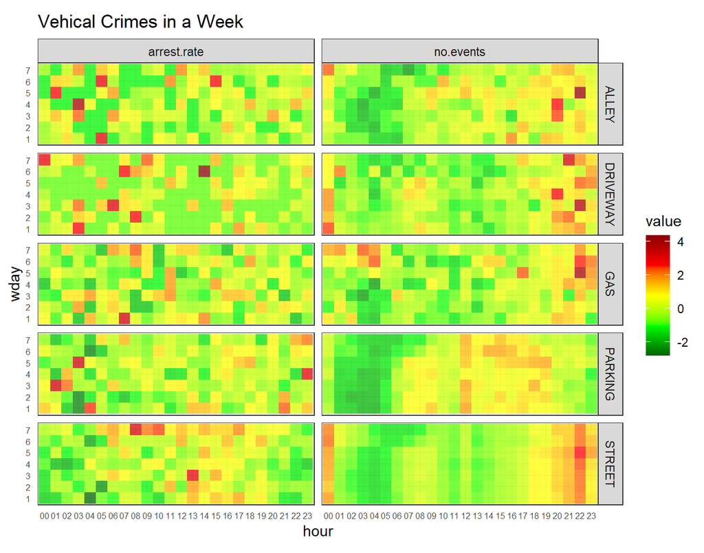

```r
L6 = table(D$Loc) %>% sort %>% tail()
D %>% mutate(ts = ts) %>%
  filter(LocationDescription %in% names(L6)[-4]) %>%
  mutate(Loc = str_remove(LocationDescription, " .*$")) %>%
  group_by(Loc, wday=format(ts,"%u"), hour=format(ts,"%H")) %>%
  summarise(no.events = n(), arrest.rate = mean(Arrest), .groups="drop") %>%
  group_by(Loc) %>% mutate_at(vars(no.events,arrest.rate), scale) %>%
  gather("key","value",4:5) %>%
  ggplot(aes(x=hour, y=wday,fill=value)) + geom_tile(alpha=0.75) +
  scale_fill_gradientn(colors=c("darkgreen","green","yellow","red","darkred")) +
  coord_fixed(ratio=1) + facet_grid(Loc~key) + theme_bw() +
  theme(axis.ticks=element_blank(),axis.text=element_text(size=6)) +
  ggtitle("Vehical Crimes in a Week")
```

💡 策略意涵：  
♞ 如果你是警方，你要如何配置警力？  
♞ 那如果你是小偷呢？

🌷 光是使用`table()`和`tapply()`和資料視覺化， 我們就已經可以從資料中找到許多有策略意涵的資訊了。